# Emirates Stadium Analysis 21/22

# **Win % in Emirates Stadium**

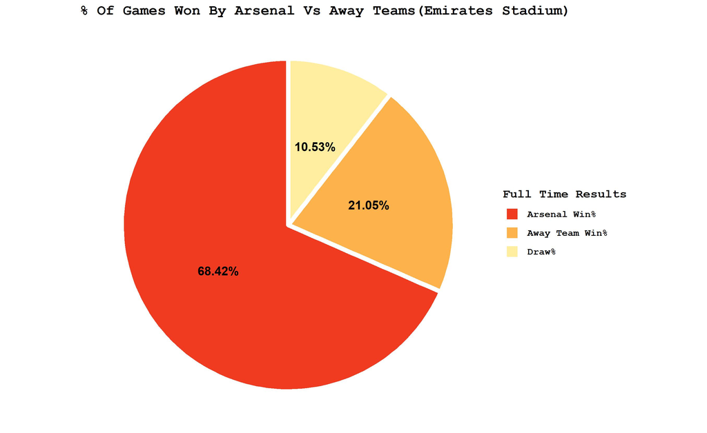

- Arsenal won a total of **68.42%** in their homeground showing a **strong dominance.**
- Away Teams won **21.05% of the total games played in emirates stadium**
- Draw results were a meagre **10.53%**

# **Distribution of Yellow Cards**

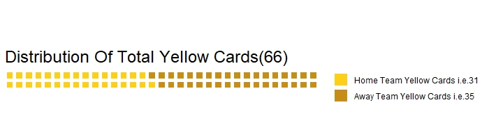

- Away team were given more yellow cards i.e. 35, hence **away teams commited more no of fouls**
- Home teams were given **31 Yellow Cards**

# Distribution of Fouls

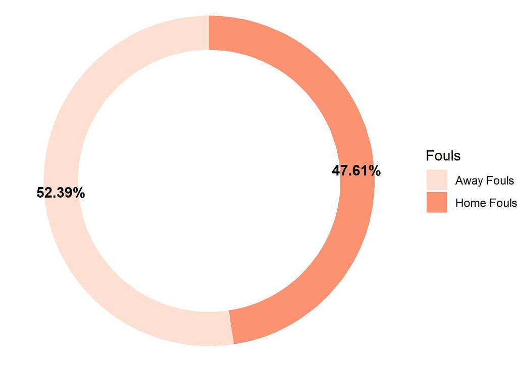

- Away Teams commited **more Fouls(i.e. 52.39%)**
- Home Teams commited **lesser Fouls(i.e. 47.61%)**
- The findings can be correlated with the number of yellow card findings and a conclusion can be drawn that **fouls commited and yellow cards given have a positive and a direct relationship.**

# No Of Goals scored by Away Teams in Emirates Stadium

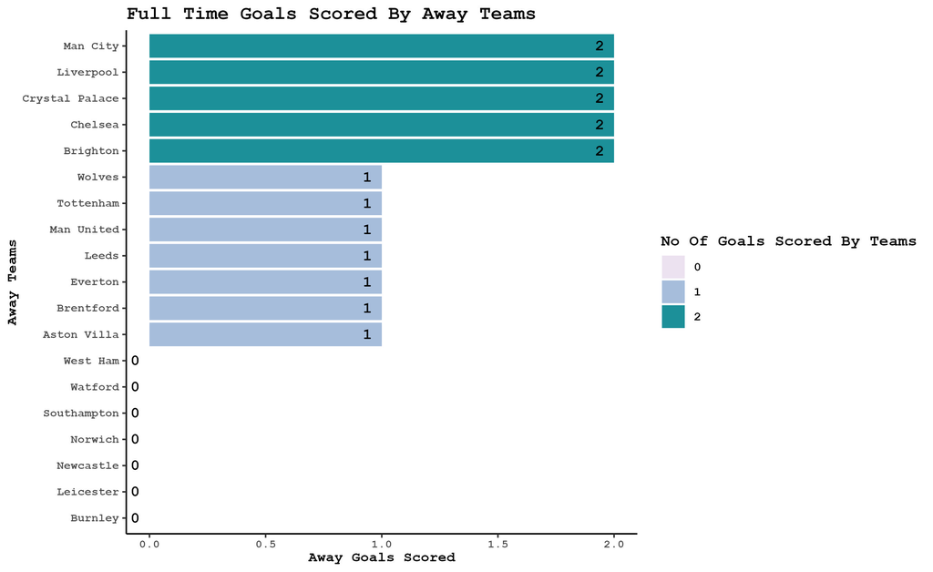

- Five teams have scored two goals in emirates stadium i.e.(**Man City, Liverpool, Crystal Palace, Brighton, Chelsea)**
- Seven teams have scored only one goal i.e. (**Wolves, Tottenham, Man United, Leeds, Everton, Brentford, Aston Villa)**
- Rest Teams haven’t been able to score in the Emirates Stadium

# Shot Distribution in Emirates Stadium(Arsenal)

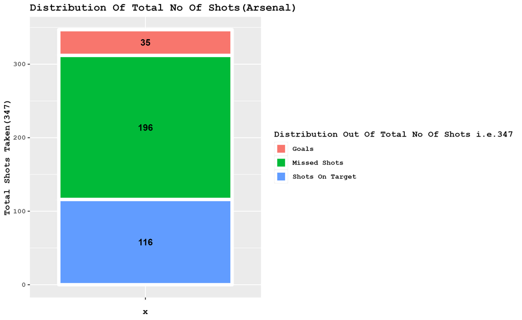

- **347 Total Shots** have been taken by Arsenal
- Out of which, **116 have been on target**
- **196 i.e. majority of shots** have resulted in misses
- **35 shots have resulted in goals**